# Project 2 Handout

Songzhu Zheng

### Big Picture Issues

This simulated study has 5 environmental variables and 15 genetic variables. The genetic variables are 0-1 indicator variables. The context of this study is that most, if not all, of the environmental variables are associated with the outcome variable. The “big picture” question is whether there are associations of the outcome variable with one or more of the genetic variables after controlling for the environmental variables. This chapter discusses the specific computer analyses and interpretations of the output to answer the important questions.

### How I Generated the Data

Below is a snippet of code which I used to generate the data. The model I used here is :

$$\log(y) = \beta_0 + \beta_1 E_1 + \beta_2 E_2 + \beta_3 G_8E_5 + \beta_4 G_{11}G_{12}+\epsilon$$

```r
set.seed(123)
library(MASS)
E <- mvrnorm(2000, mu=rep(0,5), Sigma = diag(rep(1,5)))
G <- matrix(rbinom(30000, 1, 1/2), ncol = 15)

E_index <- sort(sample(c(1,2,3,4,5), 3, replace = FALSE))
E_use <- E[, E_index]
G_index <- sort(sample(1:15, 3, replace = FALSE))
G_use <- G[,G_index]

bet <- mvrnorm(1, mu=c(100,0,0,0,0), Sigma = diag(c(1,1,1,1,1)))
Y <- exp(bet[1] + bet[2]*E_use[,1] + bet[3]*E_use[,2] + bet[4]*E_use[,3]*G_use[,1] +
        bet[5]*G_use[,2]*G_use[,3] + rnorm(2000,0,0.3))
M <- lm(I(log(Y)) ~ E_use[,1] + E_use[,2] + I(E_use[,3]*G_use[,1]) + I(G_use[,2]*G_use[,3]) )
```

Of course, you will not know the model that was used to generate your data. The data set here is :

```r
library(knitr)
Dat <- data.frame(cbind(Y, E, G))
names(Dat) <- c('Y', paste0('E', 1:5), paste0('G', 1:15))
kable( head(Dat[,1:12]), caption='Partial Data Set' )
```

Partial Data Set

| Y | E1 | E2 | E3 | E4 | E5 | G1 | G2 | G3 | G4 | G5 | G6 |
| --- | --- | --- | --- | --- | --- | --- | --- | --- | --- | --- | --- |
| 2.502487e+43 | 0.5110004 | -0.6992281 | 0.1965498 | -0.5116037 | -0.5604756 | 1 | 1 | 0 | 0 | 0 | 0 |
| 8.547419e+42 | 1.8079928 | 0.9964515 | 0.6501132 | 0.2369379 | -0.2301775 | 0 | 0 | 0 | 0 | 1 | 1 |
| 4.929691e+43 | -1.7026150 | -0.6927454 | 0.6710042 | -0.5415892 | 1.5587083 | 0 | 0 | 1 | 0 | 1 | 0 |
| 2.045099e+43 | 0.2874488 | -0.1034830 | -1.2841578 | 1.2192276 | 0.0705084 | 0 | 1 | 1 | 1 | 1 | 1 |
| 1.037183e+43 | -0.2691142 | 0.6038661 | -2.0261096 | 0.1741359 | 0.1292877 | 1 | 1 | 0 | 1 | 0 | 0 |
| 6.009527e+43 | -0.3795247 | -0.6080450 | 2.2053261 | -0.6152683 | 1.7150650 | 0 | 1 | 0 | 1 | 1 | 0 |

### Modeling the Environmental Variables

A common approach to analyzing data like this is to use just the environmental variables to explain the outcome. The command for this and the resulting output are:

```r
# Fit a model with only environmental variables
M_E <- lm(Y ~ E1+E2+E3+E4+E5, data=Dat)
summary(M_E)
```

```
##
## Call:
## lm(formula = Y ~ E1 + E2 + E3 + E4 + E5, data = Dat)
##
## Residuals:
##        Min         1Q     Median         3Q        Max
## -3.592e+43 -9.209e+42 -2.202e+42  5.733e+42  2.124e+44
##
## Coefficients:
##               Estimate Std. Error t value Pr(>|t|)
## (Intercept)  2.541e+43  3.716e+41  68.391  < 2e-16 ***
## E1          -9.762e+42  3.671e+41 -26.593  < 2e-16 ***
## E2          -1.319e+43  3.729e+41 -35.360  < 2e-16 ***
## E3           1.477e+41  3.730e+41   0.396    0.692
## E4          -6.614e+41  3.776e+41  -1.752    0.080 .
## E5           2.690e+42  3.713e+41   7.246  6.1e-13 ***
## ---
## Signif. codes:  0 '***' 0.001 '**' 0.01 '*' 0.05 '.' 0.1 ' ' 1
##
## Residual standard error: 1.661e+43 on 1994 degrees of freedom
## Multiple R-squared:  0.5139, Adjusted R-squared:  0.5127
## F-statistic: 421.6 on 5 and 1994 DF,  p-value: < 2.2e-16
```

The adjusted $R^2$ for this model could extracted by using `summary(M_E)$adj.r.squared`. The value for this model is 0.5126823.

### Modeling the Additional Contribution of the Genetic Variables

Now I assess the contribution of the genetic variables after I have controlled for the environmental variables. I assume that I only have up to 3rd order interactions. The command for a model reflecting this assumption is :

```r
# paste(paste0('E',1:5), collapse = '+')
M_raw <- lm( Y ~ (E1+E2+E3+E4+E5+G1+G2+G3+G4+G5+G6+G7+G8+G9+G10+G11+G12+G13+G14+G15)^3, data=Dat )
```

This model includes all interaction terms up to the 3rd order in the model. The next task is to create and examine the residual plot:

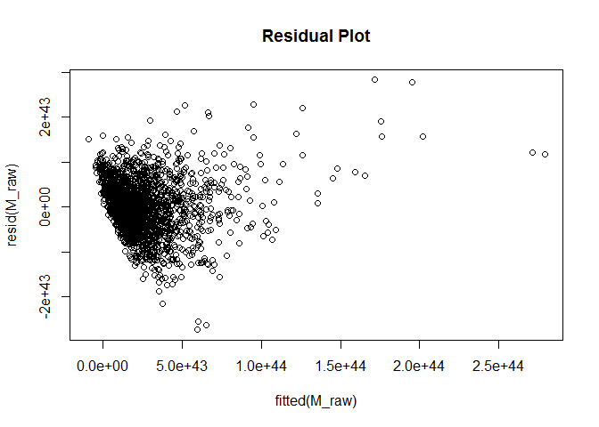

```r
plot(resid(M_raw) ~ fitted(M_raw), main='Residual Plot')
```

If the model appears to be “adequate,” I should see a flat ellipse. I see a pattern in this residual plot. The variances of the residuals appear heteroscedastic. I seek a transformation of the dependent variable that has apparently homoscedastic residuals. I could 1) try $y^2$, $y^{-1}$, $\sqrt{y}$ and $ln(y)$. or 2) use the Box-Cox transformation. The command for the Box-Cox transformation is :

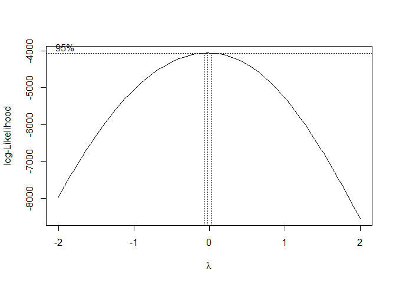

```r
boxcox(M_raw)
```

This command produced the graph above. The analyst looks for a “simple” value of $\lambda$ that maximizes the log-likelihood function. The estimated $\lambda = 0$, which implies that I should apply the logarithm transformation to our response $y$. The command for the analysis of the transformed model is

```r
M_trans <- lm( I(log(Y)) ~ (.)^3, data=Dat )
```

The commands to calculate the adjusted $R^2$ are :

```r
summary(M_raw)$adj.r.square;
```

```
## [1] 0.8002723
```

```r
summary(M_trans)$adj.r.square
```

```
## [1] 0.8397889
```

What about the residual plot? :

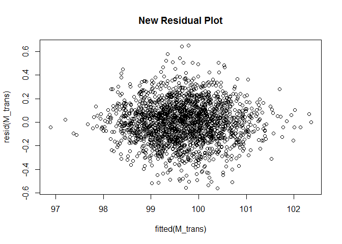

```r
plot(resid(M_trans) ~ fitted(M_trans), main='New Residual Plot')
```

This is a flat ellipse.

The adjusted $R^2$ using just the environmental variables and the original outcome was 0.513. The adjusted $R^2$ adding the genetic variables had an increased adjusted $R^2$ of 0.800; but the residual plot was not patternless. The adjusted $R^2$ with the logarithmic transformation of the outcome variable was 0.840, a notable increase from 0.800. More importantly, the residual plot was patternless. The model using logarithmic transformation has sustantially better properties than the model of the raw outcome variable. I next examine whether I can simplify the model and use stepwise regression.

### Stepwise Regression

I load the R code **leaps** and use `regsubset()` to finish my analyis. In addition to `regsubset()`, the built-in functions `step()` and `stepAIC()` in **MASS** package are alternative functions that one may use to perform stepwise regression:

```r
library(leaps)
M <- regsubsets( model.matrix(M_trans)[,-1], I(log(Y)),
                 nbest = 1 , nvmax=5,
                 method = 'forward', intercept = TRUE )
temp <- summary(M)
```

The software produces a proposed model :

```r
Var <- colnames(model.matrix(M_trans))
M_select <- apply(temp$which, 1,
                  function(x) paste0(Var[x], collapse='+'))
kable(data.frame(cbind( model = M_select, adjR2 = temp$adjr2, BIC = temp$bic)),
      caption='Model Summary')
```

Model Summary

| model | adjR2 | BIC |
| --- | --- | --- |
| (Intercept)+E2 | 0.460595242315916 | -1220.37704164264 |
| (Intercept)+E1+E2 | 0.710998123400089 | -2461.84348972152 |
| (Intercept)+E1+E2+G11:G12 | 0.805628600501046 | -3248.56918481632 |
| (Intercept)+E1+E2+E5:G8+G11:G12 | 0.842959003225845 | -3668.49826159765 |
| (Intercept)+E1+E2+E5:G8+G11:G12+E2:E5:G11 | 0.843683359808008 | -3671.14652132192 |

In this case, there is a obvious increase in $R^2_a$ from the 3rd model to the 4th model. There is only a very small increase from the 4th to the 5th model, which may not be significant. Another measure that researchers use to assess models is the Bayesian Information Criterion (BIC). The BIC values consistently decrease. The decrease from the 4th to the 5th model is much smaller than the other decreases. Consequently, I choose variables selected in the 4th model as candidates; namely E1, E2, E5, G8, G11, and G12. That is, I split the E5G8 and G11G12 interactions. Besides this, I want to also make sure **main effects** that are significant are in the model :

```r
M_main <- lm( I(log(Y)) ~ ., data=Dat)
# . here means include all variable from E1 to E5 and from G1 to G15 to the model
temp <- summary(M_main)
kable(temp$coefficients[ abs(temp$coefficients[,4]) <= 0.001, ], caption='Sig Coefficients')
```

Sig Coefficients

|  | Estimate | Std. Error | t value | Pr(>\|t\|) |
| --- | --- | --- | --- | --- |
| (Intercept) | 99.4025979 | 0.0294792 | 3371.95502 | 0 |
| E1 | -0.3734924 | 0.0074257 | -50.29722 | 0 |
| E2 | -0.4900695 | 0.0075447 | -64.95511 | 0 |
| E5 | 0.1003350 | 0.0075171 | 13.34762 | 0 |
| G11 | 0.2627861 | 0.0150169 | 17.49935 | 0 |
| G12 | 0.2859650 | 0.0150404 | 19.01308 | 0 |

The G8 variable does not have a significant main effect. I next consider the second order interactions by using the second power in the model request.

```r
M_2nd <- lm( I(log(Y)) ~ (.)^2, data=Dat)
temp  <- summary(M_2nd)
kable(temp$coefficients[ abs(temp$coefficients[,4]) <= 0.001, ], caption='2nd Interaction')
```

2nd Interaction

|  | Estimate | Std. Error | t value | Pr(>\|t\|) |
| --- | --- | --- | --- | --- |
| (Intercept) | 99.6251732 | 0.0737543 | 1350.77094 | 0 |
| E1 | -0.3592976 | 0.0275178 | -13.05693 | 0 |
| E2 | -0.5002141 | 0.0277215 | -18.04425 | 0 |
| E5:G8 | 0.1916872 | 0.0141712 | 13.52657 | 0 |
| G11:G12 | 0.4830031 | 0.0279841 | 17.25991 | 0 |

```r
M_2stage <- lm( I(log(Y)) ~ (E1+E2+E3+E5+G7+G8+G9+G11+G12+G13)^3, data=Dat)
temp <- summary(M_2stage)
temp$coefficients[ abs(temp$coefficients[,3]) >= 4, ]
```

```
##               Estimate Std. Error     t value     Pr(>|t|)
## (Intercept) 99.4805487 0.04234253 2349.423978 0.000000e+00
## E1          -0.3677504 0.03061196  -12.013292 4.735100e-32
## E2          -0.4700305 0.03307595  -14.210642 1.515986e-43
## E5:G8        0.2078914 0.03261542    6.374022 2.326421e-10
## G11:G12      0.4893503 0.05967908    8.199696 4.492289e-16
```

That is, the final model is :

$$ln(y) = \beta_0 + \beta_1 E_1 + \beta_2 E_2 + \beta_3 E_5G_8 + \beta_4 G_{11}G_{12}$$

This is exactly what I used to generate the data.

### Big Picture

Our analysis found associations with genetic variables after the environmental variables had been controlled. Specifically the G11-G12 interaction (with t-value 8.20) and the E5-G8 interaction (with t value 6.37) are significantly associated with the logarithm of the outcome variable. Including these variables significantly increased the r-squared value.

Some tips :

(1). One way to verify that your final model is correct is to put all variable you selected into a regression model without adding their interaction terms. Those variables that remain significant at the 0.001 level or have three stars are quite likely to be in the model.

(2). Variables that are significant in the main effect model are highly likely to be in the true model. Try to include these variables in your final selection, and use (1) to check.

(3). I choose terms that are significant at 0.001 level before the final fit. In the final fit I choose terms that have an absolute t-value larger than 4. Terms with absolute t value around 3.5 may or may not be in the true model. But as before, you could always check using tip (1)

(4). If results given by different transformation are similar, you could try using all of the variables and combine terms selected from all of these models. Use (1) to check in your final model.